# Beyond the Dashboard:

Automate Reporting, Elevate Storytelling

Vinnie Wu, Ph.D.

Senior Research & Planning Analyst

Fullerton College

Joshua Rhee, Ph.D.

Research and Planning Analyst

Irvine Valley College

## Sound familiar?

Common challenges with data requests

Audience

Type of Data

Primary Message

Tight Timelines

Redundancy

Building and formatting eats **precious time**.  
A reproducible, reusable template gives it back.

## Why go beyond the dashboard?

Dashboards expanded access to data, but access isn’t understanding.

**Dashboards**

- Show the numbers and filters
- Built for open-ended exploration
- Leave interpretation to the viewer

**Reports that tell the story**

- Add context and meaning
- Built for specific decisions/committees
- Point to a takeaway and next step

## Today’s session

- 0–5 min Why it matters
- 5–13 min Same data, different end product
- 13–23 min Your turn Interactive
- 23–30 min Build it once: workflow & tools
- 30–40 min Behind the scenes
- 40–45 min Q&A & reflection Interactive

Demos use **R**, but the principles apply on any reporting platform (e.g., Python, Word/PowerPoint).

# Same Data, Same Design, Different End Product

Case Study: The #RealCollegeCA Survey: Basic Needs in the CCCs

Administered 2023 · 2025 · next in 2027 (?)

## Same data, same design, different end product

**#RealCollegeCA · Version 1**

**Audience:** President’s Office  
**Purpose:** Various uses (President’s welcome talk, Board updates)  
**Product:** Electronic / physical report  
**Format:** PDF

The **President’s Office** needs main ideas, so this version is a **static page** with the takeaway written out (and printable).

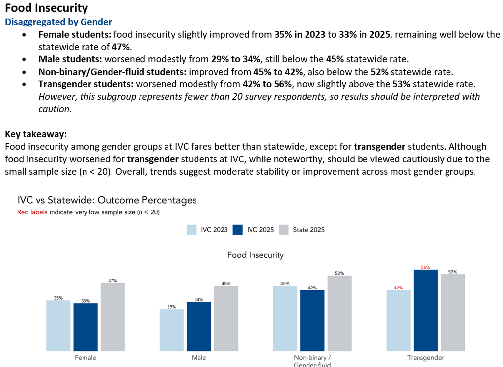

## Same data, same design, different end product

**#RealCollegeCA · Version 2**

**Audience:** Campuswide  
**Purpose:** Overview + drilldown for specific programs  
**Product:** Interactive report  
**Format:** HTML

A **campuswide** audience explores on their own, so this version is **interactive**.

**Food Insecurity by Gender**

Overall, food insecurity is most elevated among transgender and non-binary students.

[interactive chart not shown]

## Different end product, same rules

Our two reports looked different, but underneath we followed the same rules and process.

**What makes a data story work, regardless of its audience?**

Reduce cognitive load

## Reducing cognitive load

### Consistency

- Same branding and layout within and between reports
- Same chart types for similar data

### Inclusivity

- Easy to read
- Alt text
- Color contrast checking

### Sense-Making

- Interpret the data for the reader
- Same phrasing, same message for everyone
- Works at any data-literacy level
- State recommendations and next steps

Automated with templates

Where our time goes

Automation should eliminate repetitive work, not analytical thinking,  
which is why we’re **research analysts**.

## Sense-making: From data to decisions

Every report should help answer:

### What’s the key takeaway?

“Basic needs insecurities affect the majority of Fullerton College students.”

“…the magnitude of inequities varies across groups.”

### Why does it matter?

“Basic needs challenges may be linked to lower academic performance.”

### What could someone do next?

“…opportunities to continue strengthening outreach and communication.”

Quotes from FC’s 2025 #RealCollegeCA report

## Advocacy from sense-making

**Campuswide**

- Continued Healthy Hornet Meals for students
- Convocation presentation on basic needs

**With students**

- Ambassadors promoted basic needs resources
- Journalism class wrote a student article

We shared the data with students, and they became **advocates**.

[figure not shown]

# Your Turn

## ACTIVITY: How would YOU tell the story?

Campus Climate Survey: one dataset, four audiences

Assume you have the variables and/or results you need. How would you tell the story for each audience?

President’s Office

“What do I need to know?”

Faculty & staff

Campuswide email report

Student Equity Committee

“I want to know about our X students.”

Board of Trustees

“Tell me about the campus climate.”

**In your group**

1. **Identify** the key message, context, and implied action.
2. **Choose** a visualization/tool, report format, and framing for your audience.
3. **Share** in one minute: how did your audience change your choices?

# A reproducible workflow *within the report*

#RealCollegeCA 2023 → 2025 → 2027:  
build the report once, then drop in new data each cycle

## A reproducible workflow (within the report)

Raw data

Cleaning

Manual + automated

Visualization

Automated

Narrative & accessibility

Manual

Output

PDF · HTML · image

Cleaning puts data in the right “format” so everything after it can be automated.

## Consistent visualizations: design the data first

- Define the variables needed (e.g., year, groupings)
- Define predictor vs. outcome variables
- Choose the data structure (wide vs. long)
- Clean the data
- Stack survey years (2023 + 2025), so 2027 just gets appended

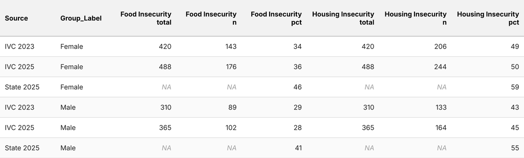

## Consistent visualizations: one function, every chart

Create a function to make the same style figures for all predictors to outcomes.

- Branding, colors, fonts
- Clean layout (gridlines, values)
- Legend
- Readable labels
- Warnings
- Export sizes

**1. Wide → long → summarize:** works for any number of groups (lines 132–150)

```r
summarise_outcomes <- function(data, student_groups, outcomes,
                               by = c("College", "year"),
                               digits = 0) {
  data %>%
    pivot_longer(all_of(student_groups),
                 names_to = "Student_Group",
                 values_to = "in_group") %>%
    filter(in_group == 1) %>%
    pivot_longer(all_of(outcomes),
                 names_to = "Outcome",
                 values_to = "has_outcome") %>%
    group_by(across(all_of(by)), Student_Group, Outcome) %>%
    summarise(total = sum(!is.na(has_outcome)),
              n = sum(has_outcome == 1, na.rm = TRUE),
              pct = round(100 * n / total, digits),
              .groups = "drop")
}
```

**2. IVC + State in one table** (lines 237–239)

```r
summary_long <-
  summarise_outcomes(ivc, student_groups, outcomes) %>%
  bind_rows(statewide) %>%
  mutate(Source = paste(College, year))
```

**3. The plot core:** one bar per source, one panel per outcome (inside make_comparison_plot)

```r
ggplot(plot_data,
       aes(x = Group_Label, y = pct, fill = Source)) +
  geom_col(position = position_dodge(width = 0.72),
           width = 0.64) +
  geom_text(aes(label = bar_label, color = low_n,
                group = Source),
            position = position_dodge(width = 0.72),
            vjust = -0.25) +
  facet_wrap(~ Outcome, nrow = 1) +
  scale_fill_manual(values = fill_colors)
# ... theme settings
```

**4. Every group x outcome combination in one loop** instead of 12 copy-pasted calls (lines 270–277)

```r
plot_grid <- expand_grid(group_set = names(group_sets),
                         outcome = outcomes)

group_plots <- pmap(plot_grid, function(group_set, outcome) {
  build_plot(group_sets[[group_set]], outcome,
             size = plot_sizes[[group_set]] %||%
               plot_sizes$default)
})
```

## The result: IVC vs. statewide

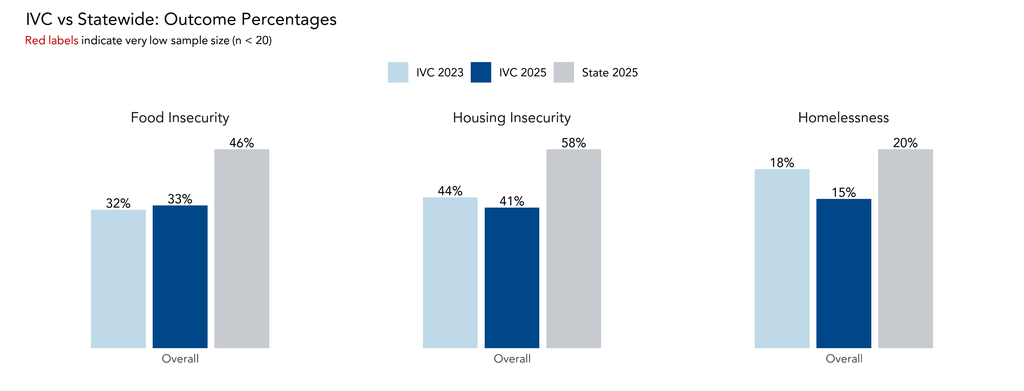

## Same function, disaggregated

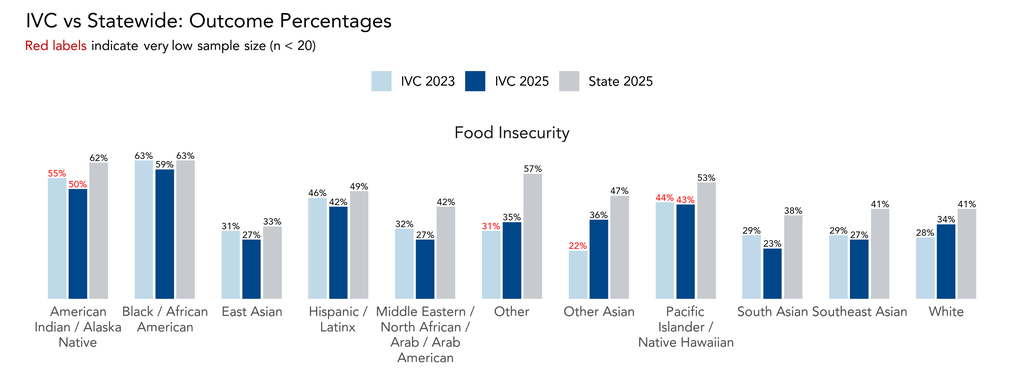

## What changes in 2027

2025: rebuild

Cleaned, charted, and formatted the #RealCollegeCA report

2027: re-render

New data in, same template, same functions, report out

The time we get back

Sense-making: interpretation, context, and recommendations for action

**Automate** the reporting, so we can **elevate** the storytelling.

# A reproducible workflow *between reports*

build the template once, then use it for multiple reports

## A reproducible workflow (between reports)

Where I started: copy `setup.R`

Paste it into each new report, then manually delete/add what’s relevant.

**Examples:** libraries, functions, themes

Where I am now: an R package

Package calls report templates, functions, and themes.

One version, loaded everywhere with `library()`.

**Examples:** `use_report(format = "pdf")`, `use_presentation()`, `+ theme_fc()`

## A reproducible workflow (between reports)

[video not shown]

## Example toolkit: R

R

- Data prep: tidyverse
- Charts: ggplot2, plotly
- Reusable chart functions
- Create a package or reusable file

**setup.R**

```r
# ---- Libraries ----
library(tidyverse) # data wrangling/viz
library(plotly) # cool charts
library(here) # file paths
library(readxl) # Excel import
library(writexl) # Excel export
library(haven) # SPSS/SAS/Stata import
library(glue) # Flexible text interpolation
library(flextable) # pretty tables
library(ggtext) # rich text in ggplot (HTML/Markdown)
library(ragg) # raster rendering for plots
library(extrafont) # font management
library(htmltools) # html in reports
library(quarto) #render quarto from R

loadfonts(device = "win", quiet = TRUE)

# ---- Fullerton College Color Palette ----
fc_colors <- c(
  "Blue" = "#0F406B",
  "Yellow" = "#FFD600",
  "Sky" = "#375E9E",
  "Creek" = "#5DCCD4",
  "Breeze" = "#BAEEED",
  "LemonZest" = "#F5F3BF",
  "Rustic" = "#E6605B",
  "Elderberry" = "#1B0D42"
)

# Neutral tone for text, lines, etc.
fc_blue <- "#0F406B"
fc_gray <- "#333333"

# ---- FC ggplot Theme ----
theme_fc <- function(base_size = 12, base_family = "Century Gothic") {
  theme_minimal(base_size = base_size, base_family = base_family) +
    theme(
      text = element_text(family = base_family, color = fc_gray),
      plot.title = element_text(
        face = "bold",
        color = fc_colors["Blue"],
        size = rel(1.2),
        hjust = 0.5
      ),
      plot.subtitle = element_text(color = fc_gray, hjust = 0.5),
      axis.title = element_text(color = fc_gray, face = "bold"),
      axis.text = element_text(color = fc_gray),
      panel.grid.major = element_line(color = "#DDDDDD"),
      panel.grid.minor = element_blank(),
      plot.caption = element_text(color = fc_gray, size = rel(0.9), hjust = 1),
      legend.title = element_text(color = fc_gray, face = "bold"),
      legend.text = element_text(color = fc_gray),
      plot.margin = margin(10, 10, 10, 10)
    )
}


# Color and fill scales for ggplot2 using the FC color palette

scale_fill_fc <- function(..., discrete = TRUE) {
  if (discrete) {
    scale_fill_manual(values = rep(unname(fc_colors), length.out = 20), ...)
  } else {
    scale_fill_gradientn(colours = unname(fc_colors), ...)
  }
}

scale_color_fc <- function(..., discrete = TRUE) {
  if (discrete) {
    scale_color_manual(values = rep(unname(fc_colors), length.out = 20), ...)
  } else {
    scale_color_gradientn(colours = unname(fc_colors), ...)
  }
}

# Set as default ggplot theme, yay!
theme_set(theme_fc())
```

## Example toolkit: Quarto

Quarto

- Reports & slides from one file
- HTML, PDF, Word
- Parameterized reports

**Why Quarto over R Markdown?**  
Better multi-language support and standardized YAML implementation

**Report template (.qmd)**

````markdown
---
title: "Report Title"
subtitle: "Subtitle or Term (e.g. Fall 2026)"
author: "Vinnie Wu"
date: today
date-format: "MMMM D, YYYY"
---


```{r}
#| label: setup
#| include: false

knitr::opts_chunk$set(echo = FALSE, message = FALSE, warning = FALSE)

source("setup.R")

```

::: {style="text-align:center;"}
<img src="../template/Library.jpg" style="width:80%; height:auto;"/>
:::

## Overview {.section-slide}

Blah blah blah

## Agenda

- First topic
- Second topic
- Third topic
- Questions & discussion
````

## Example toolkit: Templates

Templates

- One template per format: HTML, PDF, slides
- HTML & slides: CSS for branding & layout
- PDF: a print-ready template for the same look on paper

**Don’t use R?** Start by templating one recurring report in Word, PowerPoint, Tableau/PowerBI, or your coding language.

**Branding CSS**

```css
h1, h2, h3, h4 {
  font-family: var(--font-body);
  color: var(--fc-blue);
  font-weight: 700;
  margin-top: 1em;
  margin-bottom: 0.5em;
}

h1 {
  border-bottom: 2px solid var(--fc-blue);
  padding-bottom: 4px;
}

h2, h3 {
  border-inline-start: 5px solid var(--fc-blue);
  padding-inline-start: var(--space-sm);
}

h3 {
  font-style: italic;
  font-weight: 600;
}

/* Subtitle (below report title) */
#subtitle {
  font-family: var(--font-body);
  font-size: var(--subtitle-size);
  font-weight: 700;
  color: var(--fc-gray);
  letter-spacing: 0.5px;
  margin: 10px 0 32px;
  border: none !important;
}
```

## Scaling reports: parameterized reporting

# Wrap-up

## What to automate, and what not to

**Automate**

- Recurring cleaning steps
- Charts for every group
- Branding and formatting
- One report to be customized as needed

**AI can help:** debugging code, alt text, contrast checks

**Don’t automate**

- What the results mean
- Campus context and history
- Small-sample judgment calls
- Recommendations and conclusions

**AI isn’t perfect:** verifying code, checking alt text

# Thank you! Questions?

**Before you go:** think of one recurring report you build.  
What’s one improvement from today you could try on it?

QR code

Vinnie Wu · vwu@fullcoll.edu  
Joshua Rhee · jrhee@ivc.edu